# p-Value

Fri Nov 11, 2016

## Recall LC Code for Lady Tasting Tea

```r
library(ggplot2)
library(dplyr)
library(mosaic)

# Simulate many, many, many times someone guessing at random
guess_cup <- c(1, 0)
simulation <- do(10000) * resample(guess_cup, size=8)

# Count number correct
simulation <- simulation %>%
  mutate(n_correct = V1 + V2 + V3 + V4 + V5 + V6 + V7 + V8)

# Plot
ggplot(simulation, aes(x=n_correct)) +
  geom_bar() +
  labs(x="Number of Guesses Correct") +
  geom_vline(xintercept=8, col="red", size=1)
```

## Recall: Definitions

- We have two competing **hypotheses**:
  - \(H_0\): the taster is guessing at random
  - \(H_A\): the taster is not. i.e. she can really tell which came first
- The **test statistic** used here is: # of correct guesses
- The **observed test statistic** is 8 correct (out of 8)
- We going to **assume** \(H_0\) is true and see how likely the observed test statistic was.

## If She's Guessing at Random…

**Not very likely!**

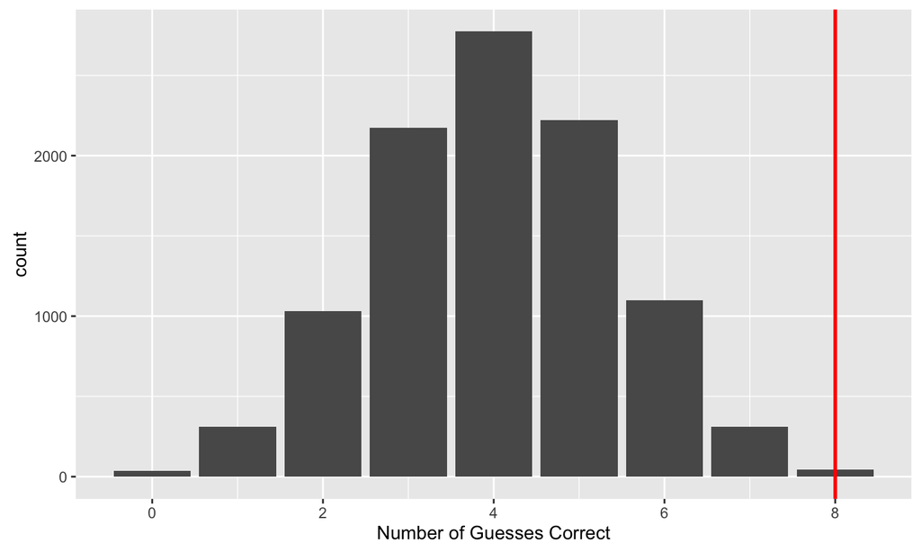

## Recall: Definitions

- The bar chart of the 10000 simulations of 8 random guesses is the **null distribution**.
- Formally: it is the distribution that describes the random behavior of the test statistic assuming \(H_0\) is true.

## Today's Single Definition

**p-value**

- Statistically: the probability of observing a test statistic as extreme as the one observed **assuming \(H_0\) is true**.
- Conceptually: measures our degree of surprise (lower = more surprised) of what we observed **assuming \(H_0\) is true**.
- Ex: how unlikely is it that the taster got 8 out of 8 right **assuming she was just guessing at random**

## Convert Counts to Proportions

Code combines the most difficult `ggplot2`/`dplyr` concepts:

- counting the different values of `n_correct` using `n()` instead of `sum()`
- dividing by the number of simulations `10000`
- using `geom_bar()` when we have an explicity `y` aesthetic `prop_correct`, so we set `stat="identity"`

```r
simulation <- simulation %>%
  group_by(n_correct) %>%
  summarise(prop_correct = n()/10000)

ggplot(simulation, aes(x=n_correct, y=prop_correct)) +
  geom_bar(stat="identity") +
  labs(x="Number of Guesses Correct", y="Proportion") +
  geom_vline(xintercept=8, col="red", size=2)
```

## How unlikely?

The proportion of times 8 occurs is 0.0050 = 0.5%.

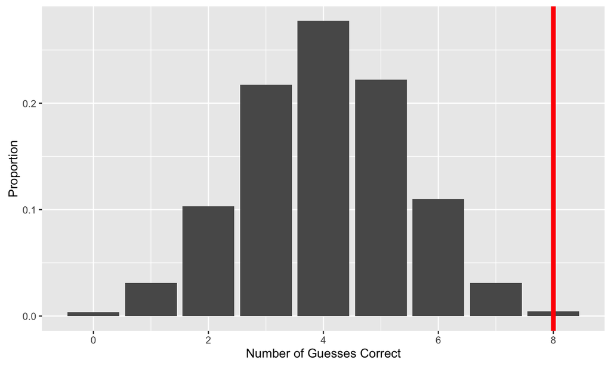

## p-Value and Conclusion

p-Value meaning:

- Conceptually: **Assuming she was guessing at random**, we are **very surprised** at observing 8 correct guesses
- Statistically: probability of observing a test statistic of 8 **assuming \(H_0\) is true** is approx. 0.5%. i.e. TINY

Study Conclusion:

- Conceptually: She was probably NOT guessing at random; she probably could tell.
- Statistically: We reject \(H_0\) in favor of \(H_A\)

## Learning Check

Say I give you a data set with two variables:

- Even or odd number of letters in last name i.e. two groups
- Test score

| num_letters | test_score |
| --- | --- |
| even | 0.7 |
| odd | 0.6 |
| odd | 0.8 |

## Learning Check

Think about how you would test:

- \(H_0\): no difference in test scores between odd vs even
- \(H_A\): there is a difference

Hints:

- Think about what assuming \(H_0\) allows you to do the data set
- Question from homework about using one of the `mosaic` package sampling tools